# Predicting the Weather for Jan. 13th 2025

```r
library(car)
library(DT)
library(tidyverse)
library(pander)
library(mosaic)
library(readxl)


# Define the file path
file_path <- "C:/Users/Jared/OneDrive/Documents/Statistics-Notebook-master/Analyses/Linear Regression/Math 425 Analysis/Weather Analysis Data.xlsx"

# Read the Excel file
Weather_Analysis_Data <- read_excel(file_path)
```

### Prediction: 28 degrees

This is a linear regression model to predict January 13Th’s max temperature in Rexburg Idaho. The wind speed (MPH) during the max temperature two days before was the independent variable. The hope of this model is that wind speed can be used to reliably predict the max temperature 2 days later.

### Question and Hypotheses

To predict the high temperature of next Monday we will start with a question, are the wind speeds of previous years a good indicator of the high temperature of a given day?

For our analysis we will use a linear regression. A linear regression is a model that uses a line to best summarize the average of the data. If we want to predict the max temperature its possible to do so by taking the wind speed and seeing where the temperature will be on the line.

Essentially we are using math to ask the question we phrased in part one. This model will follow this formula. Note it’s similar to a regular line function (y=mx+b), but it allows each dot a small amount of error off the line.
$$\underbrace{Y_i}_\text{Max Air Temp.} = \beta_0 + \beta_1
\underbrace{X_i}_\text{Wind Speed} + \epsilon_i \quad \text{where} \
\epsilon_i \sim N(0, \sigma^2)$$

For our null hypotheses we will assume there is no meaningful relationship between wind speeds and the max temperature. If beta 1 is equal to 0 there is no relationship.
$$H_0: \beta_1 = 0$$
If the null is proven wrong our alternative hypotheses will be that there is a relationship between wind speeds and a max temperature.
$$H_a: \beta_1 \neq 0$$
We want to be right 95% of the time so we will put our significance level at:
$$\alpha = 0.05$$

### Data description

The data for this analysis was gathered by taking the previous years January 11th and recording the max temperature and the wind speed at the max temperature. The site where this was collected can be found once data is shown.

### Show Data

The data for this analysis comes from https://www.timeanddate.com/weather/

#### Data

```r
# Define the file path
file_path <- "C:/Users/Jared/OneDrive/Documents/Statistics-Notebook-master/Analyses/Linear Regression/Math 425 Analysis/Weather Analysis Data.xlsx"

# Read the Excel file
Weather_Analysis_Data <- read_excel(file_path)

# View the dataset
View(Weather_Analysis_Data)
#Max air temp is for 2 days from the measurement of windspeed
datatable(Weather_Analysis_Data)
```

|  | Month | Day | Year | Humidity | WindSp | MaxAir_TempD2 |
| --- | --- | --- | --- | --- | --- | --- |
| 1 | Jan | 11 | 2024 | 0.77 | 12.428 | 10 |
| 2 | Jan | 11 | 2023 | 0.79 | 5.593 | 30 |
| 3 | Jan | 11 | 2022 | 0.72 | 4.35 | 32 |
| 4 | Jan | 11 | 2021 | 0.78 | 17.4 | 39 |
| 5 | Jan | 11 | 2020 | 0.88 | 23.614 | 27 |
| 6 | Jan | 11 | 2019 | 0.76 | 2.486 | 19 |
| 7 | Jan | 11 | 2018 | 0.82 | 5.593 | 39 |
| 8 | Jan | 11 | 2017 | 0.94 | 22.371 | 36 |

## Analysis

Here is a scatter plot of the data with the regression:

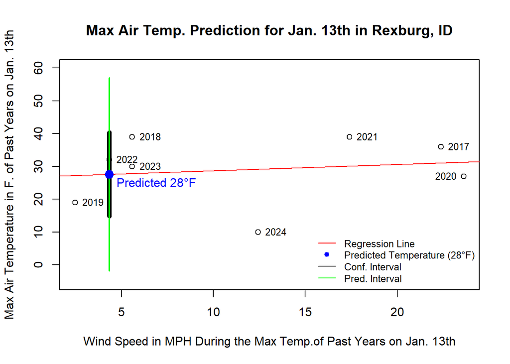

```r
# #ADD PLOT HERE
MaxTemp.lm <- lm(MaxAir_TempD2~WindSp, data = Weather_Analysis_Data)

# Scatter plot with labels
plot(MaxAir_TempD2 ~ WindSp,
     main = "Max Air Temp. Prediction for Jan. 13th in Rexburg, ID",
     ylab = "Max Air Temperature in F. of Past Years on Jan. 13th",
     xlab = "Wind Speed in MPH During the Max Temp.of Past Years on Jan. 13th",
     data = Weather_Analysis_Data,
     ylim= c(-5,60))

# Add regression line
abline(MaxTemp.lm, col = "red")

# Add year labels for each point
#with(Weather_Analysis_Data, text(WindSp, MaxAir_Temp, labels = Year, pos = 4, cex = 0.8))

positions <- c(4, 4, 4, 4, 2)  # Adjust based on the number of points
with(Weather_Analysis_Data, text(WindSp, MaxAir_TempD2, labels = Year, pos = positions, cex = 0.8))


#This is to add intervals
myweather.pred.c<- predict(MaxTemp.lm, data.frame(WindSp=4.35), interval="confidence")
myweather.pred.p<- predict(MaxTemp.lm, data.frame(WindSp=4.35), interval="predict")

lines(c(4.35,4.35),c(myweather.pred.c[2],myweather.pred.c[3]), col="black", lwd=6)
lines(c(4.35,4.35),c(myweather.pred.p[2],myweather.pred.p[3]), col="green", lwd=2)


# Add predicted point
points(4.34, 27.5, pch = 19, col = "blue", cex = 1.5)
text(4.34, 25, labels = "Predicted 28°F", pos = 4, col = "blue", cex = 1)


# Add legend
legend("bottomright",
       legend = c("Regression Line", "Predicted Temperature (28°F)", "Conf. Interval", "Pred. Interval"),
       col = c("red", "blue", "black", "green"),
       lty = c(1, NA, 1),
       pch = c(NA, 19, NA),
       bty = "n",
       cex = 0.8)
```

Now that the regression has been run the real numbers can be put into the equation for use. Notice that the $Yi$ changed and has a hat on it now. This is showing that $Yi$ is now a predicted value.
$$\underbrace{\hat{Y}_i}_\text{Predicted Max Air Temp} = 26.74 + 0.1930
\underbrace{X_i}_\text{Reported Wind Speed}$$
We can then use the formula to attempt to predict the weather for this next Monday by plugging in the potential wind speed for the day. The wind speed taken at 1/11/2025 max temperature was 4.35 MPH.Plugging that into the equation we get roughly 28 degrees. This can be seen on the graph as a blue dot.

### Show Regression Results

#### Regression Results

|  | Estimate | Std. Error | t value | Pr(>\|t\|) |
| --- | --- | --- | --- | --- |
| **(Intercept)** | 26.74 | 6.847 | 3.905 | 0.007942 |
| **WindSp** | 0.193 | 0.4837 | 0.399 | 0.7037 |

Fitting linear model: MaxAir_TempD2 ~ WindSp

| Observations | Residual Std. Error | $R^2$ | Adjusted $R^2$ |
| --- | --- | --- | --- |
| 8 | 10.84 | 0.02584 | -0.1365 |

## Conclusion

Wind speeds do not seem correlate with the high air temperature of a given day. This can be clearly seen by the graph. The points don’t exactly line up. There is quite a bit of variation from the regression. For those who know statistics, the null hypothesis can not be rejected. As seen in the regression results the wind speed was insignificant. The slope of the line produced by the wind speed is 0.193 which makes sense seeing as our R^2 suggests that the model is only accounting for around 2% of the variation in the data. In the future I hope to find something with more predictive power. Humidity levels were also tested, but also proved insignificant. One thing that can be pulled from this is that the temperature at it’s base level seemed to be 26 degrees. That’s still a little to cold for me.

## Appropriateness of the above Regression

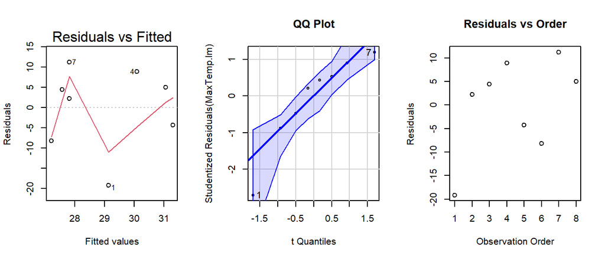

````r
# Note that this r-chunk uses ```{r, fig.height=3}
# to reduce the size of the plots. This makes the plots
# look a little nicer and also emphasizes that they are not
# as important as the main graphic (scatterplot) of the analysis.

# par(mfrow=c(1,3))
# plot(MaxTemp.lm, which=1:2)
# plot(MaxTemp.lm$residuals, main="Residuals vs Order", xlab="",
#      ylab="Residuals")

# Set up a layout for multiple plots
par(mfrow = c(1, 3))

# Plot residuals vs fitted and QQ plot
plot(MaxTemp.lm, which = 1) # Residuals vs Fitted
qqPlot(MaxTemp.lm, main = "QQ Plot") # Enhanced QQ Plot with car package

# Plot residuals vs order
plot(MaxTemp.lm$residuals, main = "Residuals vs Order",
     xlab = "Observation Order", ylab = "Residuals")
````

## Notes

Wind Speed: Wind Speed was measured by taking the max temperatures of Jan. 11 of other days and checking the speed in MPH. It is understood that during the day there is a wide fluctuation of wind speeds. This is why the wind speeds were taken at the max temperatures levels.

Note on humidity: Another Regression was run with the differing humidity levels however they failed to improve the model. Further testing needs to be done to verify this (with more than 8 points), however, the tests seem to indicate humidity levels didn’t have much predictive power over the max air temperature.

Note on Temperature: Everything was done in Fahrenheit.